# Analysis - Daims Nitrospira 5 GWW assembly

Mads Albertsen

November 24, 2015

## Introduction

This report documents the binning of a Nitrospira genome from the GWW sample. See [Daims et al., 2015: Complete Nitrification by Nitrospira Bacteria](https://doi.org/10.1038/nature16461) for further details.

## Load the mmgenome package

The metagenome data is analysed using the [mmgenome package](http://madsalbertsen.github.io/mmgenome/).

```r
library("mmgenome")
```

## Import data

The Rmarkdown file [Load_data.Rmd](http://madsalbertsen.github.io/mmgenome/Daims_GWW_Load_data.html) describes the loading of the data and can be imported using the `mmimport` function. However, the preprocessed data can also be downloaded directly from figshare: [Daims_GWW](http://dx.doi.org/10.6084/m9.figshare.1613284). Hence, here we import the prepocessed data from figshare instead.

```r
load("Daims_GWW.RData")
```

## Extract Nitrospira 5

As seen from the overview plots, there are numerous Nitrospira species. This one is located between multiple other species.

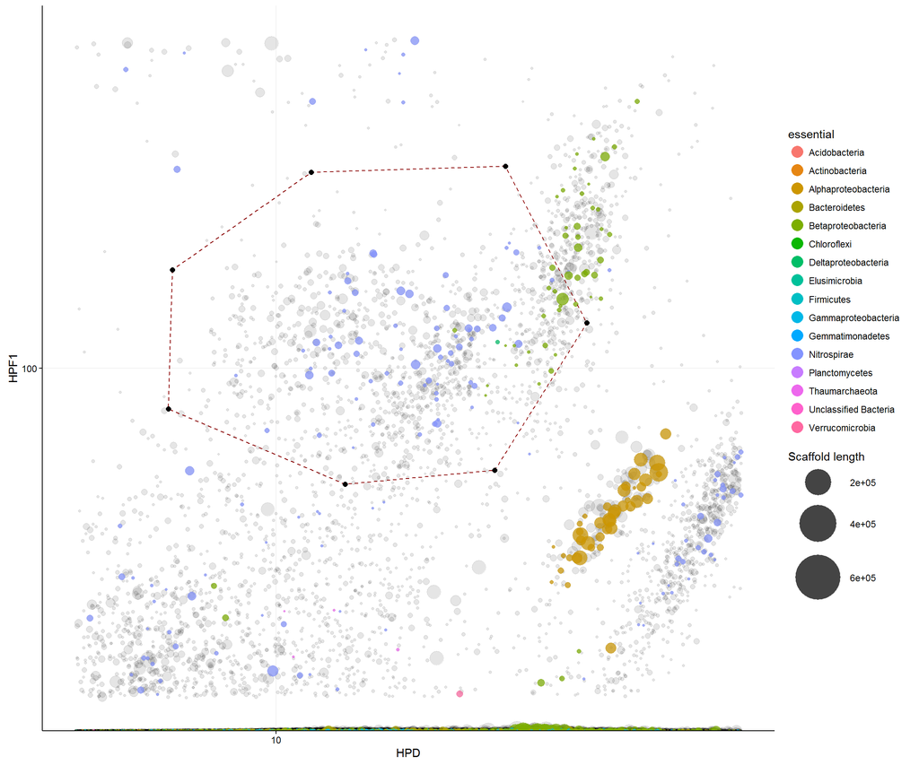

```r
p <- mmplot(data = d,
            x = "HPD",
            y = "HPF1",
            color = "essential",
            minlength = 1000,
            factor.shape = "solid") +
  scale_x_log10(limits=c(5, 50)) +
  scale_y_log10(limits=c(50, 200))

#p
#sel <- mmplot_locator(p)

sel <- data.frame(HPD  =  c(6.99, 6.89, 12.7, 21.3, 29.3, 22.1, 11.3),
                  HPF1  =  c(123, 91.8, 78.4, 80.7, 110, 153, 151))

mmplot_selection(p, sel)
```

The scaffolds included in the defined subspace are extracted using the `mmextract` function.

```r
dA <- mmextract(d, sel)
```

The `mmstats` function applies to any extracted object. Hence, it can be used directly on the subset.

```r
mmstats(dA, ncov = 2)
```

```
##               General Stats
## n.scaffolds         1215.00
## GC.mean               54.60
## N50                 6720.00
## Length.total     5568348.00
## Length.max         42005.00
## Length.mean         4583.00
## Coverage.HPD          16.71
## Coverage.HPF1        105.41
## Ess.total            188.00
## Ess.unique           100.00
```

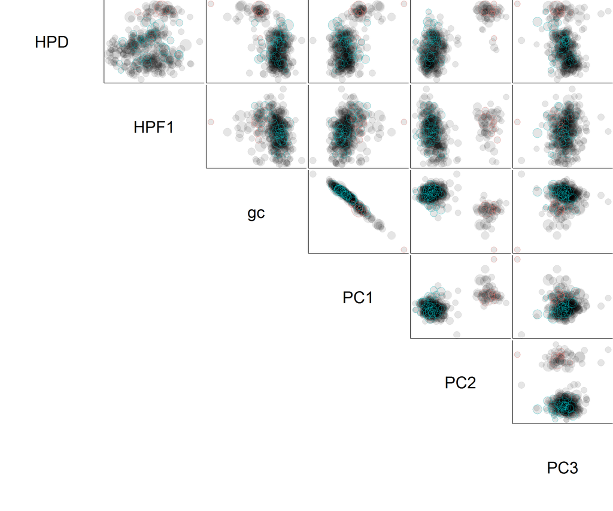

```r
mmplot_pairs(data = dA,
             variables = c("HPD", "HPF1","gc", "PC1", "PC2", "PC3"),
             minlength = 5000,
             color = "essential")
```

## Clean-up other species (Subset B)

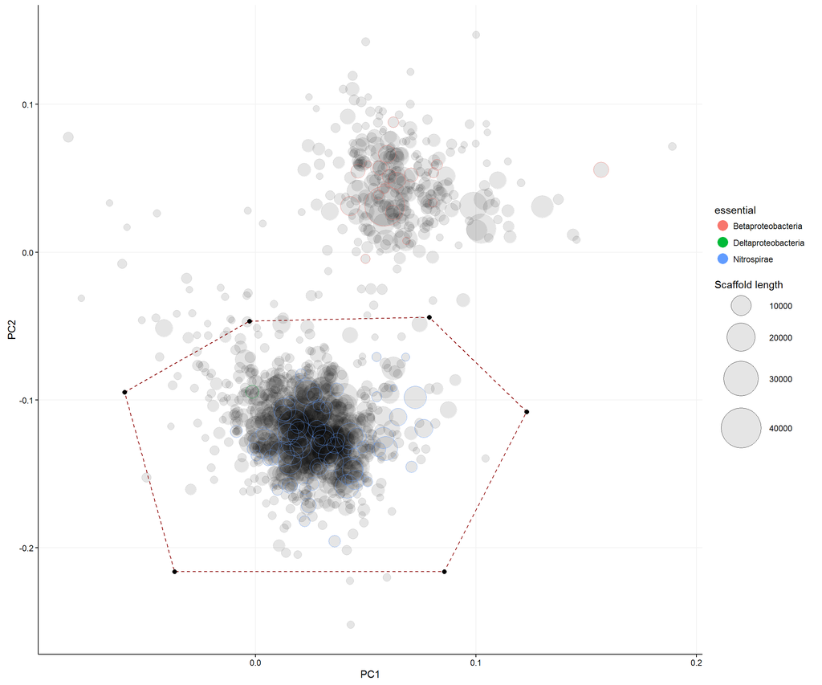

```r
p <- mmplot(data = dA,
            x = "PC1",
            y = "PC2",
            color = "essential",
            minlength = 1000)
#p
#sel <- mmplot_locator(p)

sel <- data.frame(PC1  =  c(-0.0593, -0.00267, 0.0788, 0.123, 0.0856, -0.0366),
                  PC2  =  c(-0.0948, -0.0467, -0.0439, -0.108, -0.216, -0.216))

mmplot_selection(p, sel)
```

The scaffolds included in the defined subspace are extracted using the `mmextract` function. A few scaffolds are excluded based on network plots.

```r
dB <- mmextract(dA, sel, exclude = c("9076", "19430"))
```

The `mmstats` function applies to any extracted object. Hence, it can be used directly on the subset.

```r
mmstats(dB, ncov = 2)
```

```
##               General Stats
## n.scaffolds          900.00
## GC.mean               55.50
## N50                 7151.00
## Length.total     4435667.00
## Length.max         42005.00
## Length.mean         4928.50
## Coverage.HPD          14.77
## Coverage.HPF1        104.31
## Ess.total            151.00
## Ess.unique            97.00
```

## Export the scaffolds

Finally the binned scaffolds are exported.

```r
mmexport(data = dB, assembly = assembly, file = "GWW_Nitrospira5.fa")
```